# Hedging with Put Options

Anna Xu  
November 13th, 2016

### Background

Hedging is an investment strategy that reduces the risk of adverse price movements for a given asset. Often it refers to offsetting a position with a call or put option. In this presentation, I will show how buying S&P 500 put options can reduce the risk in an investor's position.

Interesting Things To Know About Options:

- Option prices move faster in response to the news
- Market makers maintain larger bid-ask spreads for options, which can represent a large fraction of the option's overall price
- If you hold an option for less than one year, the profit is taxed at ordinary income rates, but if you hold it for longer, it is taxed as long term capital gains.
- A position is the amount of security, commodity or currency that is owned and then sold by an individual.
- A popular hedging strategy is buying call and put options to offset losses. Here, we will look only at the effects of purchasing put options.

### Example

Assume that an investor owns **$1,000,000** worth of the S&P 500 mutual fund and is concerned it may dip.

- He is willing to spend **1.696%** of his position value (or $16960) to hedge his portfolio for one month.
- The S&P 500 index (SPX) is worth **$2,111.72**.
- The cost of one SPX put option that expires one month with a strike price equal to the current price is **$42.40**.
- We know that $16960 can purchase a total of **4** contracts because $42.40 (put option ask price) * 4 (number of contracts) * 100 (option multiplier) = $16960.

(Data is from Nov 1st, 2016 at 4:30 PM and was found on marketwatch.com)

### Programming

Let's say we want to understand how the increase or decrease in the S&P 500 after one month affects the investor's portfolio after he buying these 4 put options. We write an R program for the situation as follows:

```r
P=1000000        #Amount of money being invested
Perc=.01696      #Percentage allocated to put options
SPX = 2111.72    #SPX price
numPuts=4        #Total number of put options bought
ask = 42.40      #Ask price for a put
SPXperc = c(seq(-0.5,0.5,0.05))#Potential percentage change of SPX price
```

- Here we have simply inputted the values given to us by the example.

### Programming Pt. 2

```r
SPXvalue = SPX * (1 + SPXperc)  #SPX price after one month
Putvalue = (pmax(SPX-SPXvalue, 0))*numPuts*100  #Value of the 4 SPX puts
Positionvalue = (P*(1-Perc))*(1+SPXperc) #Position Value
Position_value_with_puts = Positionvalue + Putvalue  #Position value with SPX puts
Hedgeperc = (Position_value_with_puts-P)/P   #Hedged Portfolio Percentage Change
```

- **SPX price after one month** is calculated by multiplying the current SPX price by 1 plus the percentage growth.
- **Value of the the 4 SPX puts** is the value of the puts at expiration. If the SPX decreased, this value is the difference in the SPX prices at the beginning and end of the month. If the SPX increased, the put options are worth 0. Finally, it is multiplied by the number of puts bought and the option multiplier.
- **Position Value** is the remaining money invested into SPX ($1,000,000-$16,960) multiplied by 1 + the SPX percentage growth.
- **Position value with SPX puts** is the Position Value plus the Value of the SPX puts at expiration. This is the final position value after one month.
- Finally, the **Hedged Portfolio Percentage Change** is the final position value minus the original $1,000,000 divided by the original $1,000,000. This is how much your entire position has changed after one month.

### Table

Here we can see a table of the values calculated previously. Note, only the head of the table is shown.

```
--------------------------------------------------------------------------
 SPXperc   SPXvalue   Putvalue   Positionvalue   Position_value_with_puts
--------- ---------- ---------- --------------- --------------------------
  -0.5       1056      422344       491520                913864

  -0.45      1161      380110       540672                920782

  -0.4       1267      337875       589824                927699

  -0.35      1373      295641       638976                934617

  -0.3       1478      253406       688128                941534

  -0.25      1584      211172       737280                948452

  -0.2       1689      168938       786432                955370

  -0.15      1795      126703       835584                962287

  -0.1       1901      84469        884736                969205

  -0.05      2006      42234        933888                976122

    0        2112        0          983040                983040

  0.05       2217        0          1032192              1032192

   0.1       2323        0          1081344              1081344

  0.15       2428        0          1130496              1130496

   0.2       2534        0          1179648              1179648

  0.25       2640        0          1228800              1228800

   0.3       2745        0          1277952              1277952

  0.35       2851        0          1327104              1327104

   0.4       2956        0          1376256              1376256
```

[output cut: 39 more lines]

```

  0.1796

  0.2288

   0.278

  0.3271

  0.3763

  0.4254

  0.4746
-----------
```

### Plot

We can visualize our results on the following plot showing the relationship our hedged portfolio and how much the SPX increases/decreases. There is a linear relationship between the two, but clearly first slope is less steep. This can be interpreted as: a swift decrease in SPX results in a moderate decrease in our position's value.

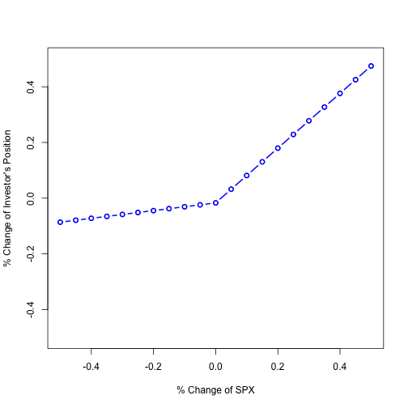

### Varying the Number of Put Options

What if instead of purchasing 4 puts, we purchase 2, 3, 5, or 6 puts? While the gain from SPX hardly changes, the risk is increasingly minimized as an investor purchases more put options. If the investor purchases 5 or 6 puts, then the portfolio is worth more as the SPX drops because the value of the put options is so large.

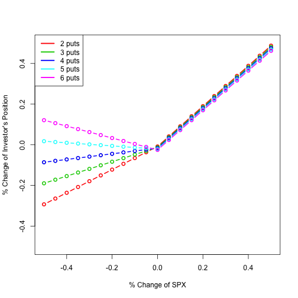

### In Conclusion:

- Buying put options is an effective way of hedging your portfolio and minimizing risk.
- The level of effectiveness depends on how many put options are purchased.
- Purchasing put options minimally affects the gains from a stock price increasing.
- Even the difference between one percentage point invested in put options makes a huge difference.
- Investors can use the code in this presentation to visualize their own portfolios.

### Citations

- http://www.investopedia.com/terms/p/position.asp
- http://www.investopedia.com/university/options/
- http://www.investopedia.com/articles/basics/03/080103.asp
- http://www.fool.com/investing/general/2015/05/01/thinking-of-trading-options-here-are-3-things-you.aspx
- http://optionboost.com/
- http://www.schwab.com/public/schwab/active_trader/trading_insights/options/how_to_hedge_your_portfolio.html
- http://finance.yahoo.com/quote/SPW.SG?p=SPW.SG
- http://www.marketwatch.com/investing/index/spx/options